# 2 Chapter 4: Under the Hood: Training a Digit Classifier

Download MNIST dataset, and sepearate into training, validation and test sets:

```julia
threes = sort(readdir(joinpath(data_path, "train", "3")))
sevens = sort(readdir(joinpath(data_path, "train", "7")))

threes
```

```
6131-element Vector{String}:
 "10001.png"
 "10012.png"
 "10032.png"
 "10035.png"
 "10043.png"
 "10053.png"
 "10075.png"
 "1008.png"
 "10092.png"
 "10094.png"
 "10098.png"
 "10100.png"
 "10117.png"
 ⋮
 "9905.png"
 "9914.png"
 "9916.png"
 "9917.png"
 "993.png"
 "9933.png"
 "9954.png"
 "9960.png"
 "9975.png"
 "9978.png"
 "999.png"
 "9992.png"
```

```julia
im3_path = joinpath(data_path, "train", "3", threes[1])
im3 = load(joinpath(im3_path))
```

```julia
im3_array = convert(Array{Int}, im3 * 255)
im3_array[4:10, 4:10]
```

```
7×7 Matrix{Int64}:
 0  0    0    0    0    0    0
 0  0    0    0    0    0    0
 0  0    0    0    0    0   29
 0  0    0    0   48  166  224
 0  0   93  244  249  253  187
 0  0  107  253  253  230   48
 0  0    3   20   20   15    0
```

```julia
seven_tensors = [load(joinpath(data_path, "train", "7", seven)) for seven in sevens]
three_tensors = [load(joinpath(data_path, "train", "3", three)) for three in threes]
size(seven_tensors), size(three_tensors)
```

```
((6265,), (6131,))
```

```julia
three_tensors[1]
size(three_tensors[1])
size(three_tensors)
```

```
(6131,)
```

```julia
stacked_sevens = MLUtils.stack(seven_tensors)
stacked_threes = MLUtils.stack(three_tensors)
size(stacked_sevens), size(stacked_threes)
```

```
((28, 28, 6265), (28, 28, 6131))
```

Alternatively one can create seven_tensors and three_tensors directly from MLUDatasets:

```julia
dataset = MLDatasets.MNIST(:train)

stacked_sevens = dataset.features[:, :, dataset.targets.==7]
stacked_threes = dataset.features[:, :, dataset.targets.==3]

size(stacked_sevens), size(stacked_threes)
```

```
((28, 28, 6265), (28, 28, 6131))
```

```julia
# length(size(stacked_threes))
ndims(stacked_threes)
```

```
3
```

```julia
### need to transpose the dimensions

stacked_sevens = permutedims(stacked_sevens, [2, 1, 3])
stacked_threes = permutedims(stacked_threes, [2, 1, 3])

convert(Array{Gray}, hcat(stacked_sevens[:, :, 1], stacked_threes[:, :, 1]))
```

```julia
mean3 = mean(stacked_threes, dims=3)
mean3 = mean3[:, :, 1]

convert(Array{Gray}, mean3)
```

```julia
mean7 = mean(stacked_sevens, dims=3)
mean7 = mean7[:, :, 1]

convert(Array{Gray}, mean7)
```

```julia
a_3 = stacked_threes[:, :, 1]
dist_3_abs = mean(abs.(a_3 .- mean3))
dist_3_sqr = sqrt(mean((a_3 .- mean3) .^ 2))
dist_3_abs, dist_3_sqr
```

```
(0.12612005f0, 0.23508778f0)
```

```julia
Flux.Losses.mae(a_3, mean3), sqrt(Flux.Losses.mse(a_3, mean3))
```

```
(0.12612005f0, 0.23508778f0)
```

## 2.1 Computing Metrics Using Broadcasting

The rule of broadcasting in Julia is different from Python? In Python, first align all dimensions to the right, then broadcast. In Julia, first align all dimensions to the left, then broadcast. So in python [1000, 28, 28] - [28, 28] is allowed, but in Julia, we need [28, 28, 1000] - [28, 28]. Use `permutedims` to change the order of dimensions.

```julia
valid_threes = sort(readdir(joinpath(data_path, "test", "3")))
valid_3_tens = MLUtils.stack([load(joinpath(data_path, "test", "3", img)) for img in valid_threes])

valid_sevens = sort(readdir(joinpath(data_path, "test", "7")))
valid_7_tens = MLUtils.stack([load(joinpath(data_path, "test", "7", img)) for img in valid_sevens])

# valid_3_tens = permutedims(valid_3_tens, [3, 1, 2])

size(valid_3_tens), size(valid_7_tens)
```

```
((28, 28, 1010), (28, 28, 1028))
```

```julia
function mnist_distance(a, b)
    mm = mean(Float32.(abs.(a .- b)), dims=(1, 2))
    return dropdims(mm, dims=(1, 2))
end

mnist_distance(a_3, mean3)[1]
```

```
0.12612005f0
```

```julia
valid_3_dist = mnist_distance(valid_3_tens, mean3)
(size(valid_3_dist), valid_3_dist)
```

```
((1010,), Float32[0.12803426, 0.16230617, 0.12421783, 0.14686641, 0.120200165, 0.118782386, 0.16995831, 0.12664512, 0.13367367, 0.11829293  …  0.12947088, 0.1525875, 0.1556588, 0.13255748, 0.13654083, 0.17447978, 0.12789737, 0.15078008, 0.12630658, 0.12596397])
```

```julia
size(valid_3_tens .- mean3)
```

```
(28, 28, 1010)
```

```julia
is_3(x) = mnist_distance(x, mean3) .< mnist_distance(x, mean7)
```

```
is_3 (generic function with 1 method)
```

```julia
is_3(a_3)
is_3(valid_3_tens[:, :, 1:10])

is_3(valid_7_tens[:, :, 1:10])
```

```
10-element BitVector:
 0
 0
 0
 0
 0
 0
 0
 0
 0
 0
```

```julia
accuracy_3s = mean(is_3(valid_3_tens))
accuracy_7s = mean(1 .- is_3(valid_7_tens))

accuracy_3s, accuracy_7s
```

```
(0.9168316831683169, 0.9854085603112841)
```

## 2.2 Calculating Gradients

### 2.2.1 Using [`Flux.jl`](https://fluxml.ai/Flux.jl/stable/models/basics/)

Taking gradients in `Flux.jl` is as simple as calling `gradient` on a function. For example, to take the gradient of `f(x) = x^2` at `x = 2`, we can do the following:

```julia
f(x) = x^2
df(x) = gradient(f, x)[1]
df(2)
```

```
4.0
```

Below we implement and visualise gradient descent from scratch in Julia.

```julia
xmax = 10
n = 100
plt = plot(
    range(-xmax, xmax, length=n), f;
    label="f(x)", lw=5, xlim=1.5 .* [-xmax, xmax],
    xlab="Parameter", ylab="Loss", legend=false
)

nsteps = 10
lrs = [0.05, 0.3, 0.975, 1.025]
descend(x; lr=0.1) = x - lr * df(x)
x = [-0.75xmax]
x = repeat(x, length(lrs), 1)                             # repeat x for each learning rate
plts = [deepcopy(plt) for i in 1:length(lrs)]           # repeat plt for each learning rate
anim = @animate for j in 1:nsteps
    global x = hcat(x, zeros(size(x, 1)))                # add column of zeros to x
    for (i, lr) in enumerate(lrs)
        _plt = plot(plts[i], title="lr = $lr", ylims=(0, f(xmax)), legend=false)
        scatter!([x[i, j]], [f(x[i, j])]; label=nothing, ms=5, c=:red)    # plot current point
        x[i, j+1] = descend(x[i, j]; lr=lr)                               # descend
        Δx = x[i, j+1] - x[i, j]
        Δy = f(x[i, j+1]) - f(x[i, j])
        quiver!([x[i, j]], [f(x[i, j])], quiver=([Δx], [0]), c=:red)          # horizontal arrow
        quiver!([x[i, j+1]], [f(x[i, j])], quiver=([0], [Δy]), c=:red)        # vertical arrow
        plts[i] = _plt
    end
    plot(
        plts..., legend=false,
        plot_title="Step $j", margin=5mm,
        dpi=300,
    )
end
gif(anim, joinpath(www_path, "c4_gd.gif"), fps=0.5)
```

[figure not shown]

Figure 2.1: Gradient descent for different learning rates

## 2.3 An End-to-End SGD Example

```julia
## is time a good variable name?
time = collect(range(start=0, stop=19))

speed = @. $rand(20) + 0.75 * (time - 9.5)^2 + 1

scatter(time, speed, legend=false, xlabel="time", ylabel="speed")
```

[figure not shown]

```julia
function f(t, params)
    a, b, c = params
    return @. a * (t - b)^2 + c
end

function mse(preds, targets)
    return sum((preds .- targets) .^ 2) / length(preds)
end
```

```
mse (generic function with 1 method)
```

```julia
function show_preds(preds)
    scatter(time, speed)
    scatter!(time, preds, color="red")
end
```

```
show_preds (generic function with 1 method)
```

```julia
params = rand(3)
preds = f(time, params)

show_preds(preds)
```

[figure not shown]

```julia
loss = mse(preds, speed)
```

```
8296.82143644548
```

```julia
dloss(params) = gradient(params -> mse(f(time, params), speed), params)

grad = dloss(params)[1]

lr = 1e-5
params = params .- lr .* grad

preds = f(time, params)
mse(preds, speed)

show_preds(preds)
```

[figure not shown]

```julia
## params will be updated in place
function apply_step!(params; lr=1e-5, prn=true)
    grad = dloss(params)[1]
    params .-= lr * grad ## inplace update
    preds = f(time, params)
    loss = mse(preds, speed)
    if prn
        println(loss)
        println(grad)
        println(params)
    end
    return preds
end
```

```
apply_step! (generic function with 1 method)
```

```julia
params = rand(3)
plts = []

for i in range(1, 4)
    push!(plts, show_preds(apply_step!(params; lr=0.0001, prn=false)))
end

plot(
    plts..., legend=false,
    plot_title="First four steps", margin=5mm,
    dpi=300,
)
```

[figure not shown]

```julia
params = rand(3)
preds = f(time, params)

plts = []
push!(plts, show_preds(preds))

lr = 0.0001  ## how to adjust learning rate? takes a lot of time to learn
for i in range(0, 60000)
    apply_step!(params, prn=false)
end

preds = apply_step!(params, prn=true);
push!(plts, show_preds(preds))

plot(
    plts..., legend=false,
    plot_title="After 60000 steps", margin=5mm,
    dpi=300,
)
```

```
10.90886132109632
[-0.0735022149927751, -0.0003901579811111944, 4.383430999602089]
[0.6672579211758306, 9.493901611682551, 6.352134871734056]
```

[figure not shown]

## 2.4 The MNIST Loss Function

```julia
train_x = cat(stacked_threes, stacked_sevens, dims=3) |> x -> reshape(x, 28 * 28, :) |> transpose;
train_y = vcat(repeat([1], size(stacked_threes)[3]), repeat([0], size(stacked_sevens)[3]));

size(train_x), size(train_y)
```

```
((12396, 784), (12396,))
```

```julia
dset = [(train_x[i, :], train_y[i]) for i in range(1, size(train_x)[1])]
x, y = dset[1]
size(dset), size(x), y
```

```
((12396,), (784,), 1)
```

```julia
valid_x = cat(valid_3_tens, valid_7_tens, dims=3) |> x -> reshape(x, 28 * 28, :) |> transpose;
valid_y = vcat(repeat([1], size(valid_3_tens)[3]), repeat([0], size(valid_7_tens)[3]));
valid_dset = zip(eachrow(valid_x), valid_y);

size(valid_x), size(valid_y), size(valid_dset)
```

```
((2038, 784), (2038,), (2038,))
```

```julia
init_params(size; std=1.0) = randn(size) * std

weights = init_params((28 * 28, 1))

bias = init_params(1)

size(weights), size(bias)
```

```
((784, 1), (1,))
```

```julia
train_x = convert(Array{Float32}, train_x)

train_x[1:1, :] * weights .+ bias
```

```
1×1 Matrix{Float64}:
 -3.501327342352872
```

Pytorch tensor provides a tag to indicate if gradient is to be computed. This is not needed in Flux? To get gradient, just use gradient function in Flux

```julia
gradient(weights -> sum(train_x[1:1, :] * weights), weights)
```

```
([0.0; 0.0; … ; 0.0; 0.0;;],)
```

```julia
linear1(xb) = xb * weights .+ bias
preds = linear1(train_x)
```

```
12396×1 Matrix{Float64}:
  -3.501327342352871
  -7.803989646297762
   0.6762347534331052
  -3.023752660788845
  -9.516878292448476
  -7.033978158406221
  -4.121724962898755
   7.818492504419868
  -2.4782311140758995
   3.779727107749914
  -3.408244480726173
  -7.060928958728613
  -2.1788888600992573
   ⋮
   9.819611612539923
   0.8538666355803137
   2.3249911800591567
  -3.8884379846078874
  -4.1295855377706445
  -0.14468002821284043
   1.5411110361966878
  -6.228736530914673
  -2.1027676354594456
 -11.00265384543037
  -0.504937167730418
   4.139620206286243
```

```julia
corrects = (preds .> 0.0) .=== Bool.(train_y)

mean(corrects)
```

```
0.6069699903194579
```

```julia
weights[1] *= 1.0001

preds = linear1(train_x)
mean((preds .> 0.0) .== Bool.(train_y))
```

```
0.6069699903194579
```

```julia
trgts = [1, 0, 1]
prds = [0.9, 0.4, 0.2]

mnist_loss(predictions, targets) = mean(t === 1 ? 1 - p : p for (p, t) in zip(predictions, targets))

mnist_loss(prds, trgts), mnist_loss([0.9, 0.4, 0.8], trgts)
```

```
(0.43333333333333335, 0.2333333333333333)
```

```julia
sigmoid(x) = 1 / (1 + exp(-x))

print(sigmoid.(rand(10)))

plot(range(-5, 5, length=100), sigmoid)
```

```
[0.6410273776045075, 0.6105076166250384, 0.5783704340117538, 0.6426148235103056, 0.6852254892841372, 0.5984580626393032, 0.6717542924899141, 0.517005739780998, 0.5656790579343766, 0.6485622582089181]
```

[figure not shown]

```julia
function mnist_loss(predictions, targets)
    predictions = sigmoid.(predictions)
    return mean([t === 1 ? 1 - p : p for (p, t) in zip(predictions, targets)])
end
```

```
mnist_loss (generic function with 1 method)
```

## 2.5 SGD and Mini-Batches

```julia
coll = range(1, 15)

dl = DataLoader((coll), batchsize=5, shuffle=true)

collect(dl)
```

```
3-element Vector{Vector{Int64}}:
 [2, 4, 8, 1, 10]
 [12, 14, 7, 15, 3]
 [6, 9, 11, 5, 13]
```

```julia
lowercase_alphabets = 'a':'z' ## [Char(i) for i in 97:122]

ds = [ (i, v) for (i, v) in enumerate(lowercase_alphabets)]

dl = DataLoader(ds, batchsize=5, shuffle=true)
collect(dl)
```

```
6-element Vector{Vector{Tuple{Int64, Char}}}:
 [(13, 'm'), (24, 'x'), (2, 'b'), (4, 'd'), (26, 'z')]
 [(20, 't'), (25, 'y'), (12, 'l'), (22, 'v'), (18, 'r')]
 [(15, 'o'), (7, 'g'), (5, 'e'), (3, 'c'), (11, 'k')]
 [(23, 'w'), (16, 'p'), (1, 'a'), (6, 'f'), (21, 'u')]
 [(14, 'n'), (8, 'h'), (9, 'i'), (19, 's'), (10, 'j')]
 [(17, 'q')]
```

Does dataloader work with files and directories?

```julia
weights = init_params((28*28,1))
bias = init_params(1)
size(weights), size(bias)
```

```
((784, 1), (1,))
```

```julia
function reformat_dl(d1)
    xb = MLUtils.stack([x for (x, y) in d1], dims=1)
    yb = MLUtils.stack([[y] for (x, y) in d1], dims=1)
    return xb, yb
end

dl = DataLoader(dset, batchsize=256, shuffle=true)

d1 = first(dl)
length(d1)

xb, yb = reformat_dl(d1)

size(xb), size(yb)
```

```
((256, 784), (256, 1))
```

```julia
valid_x = convert(Array{Float32}, valid_x)

valid_dset = [(valid_x[i, :], valid_y[i]) for i in range(1, size(valid_x)[1])]

valid_dl = DataLoader(valid_dset, batchsize=256, shuffle=true)
```

```
8-element DataLoader(::Vector{Tuple{Vector{Float32}, Int64}}, shuffle=true, batchsize=256)
  with first element:
  256-element Vector{Tuple{Vector{Float32}, Int64}}
```

```julia
batch = train_x[1:4, :]
size(batch)

preds = linear1(batch)

loss = mnist_loss(preds, train_y[1:4])

## redefine linear layer to include weights and bias as parameters

linear1(xb, weights, bias) = xb * weights .+ bias
preds = linear1(batch, weights, bias)

curr_gr = gradient(weights, bias) do weights, bias
    preds = linear1(batch, weights, bias)
    mnist_loss(preds, train_y[1:4])
end
```

```
([0.0; 0.0; … ; 0.0; 0.0;;], [-0.00019200529295718371])
```

```julia
# using dictionary to store parameters

params = Dict("weights" => weights, "bias" => bias)

linear1(xb, params) = xb * params["weights"] .+ params["bias"]

curr_gr = gradient(params) do params
    preds = linear1(batch, params)
    mnist_loss(preds, train_y[1:4])
end
```

```
(Dict{Any, Any}("weights" => [0.0; 0.0; … ; 0.0; 0.0;;], "bias" => [-0.00019200529295718371]),)
```

```julia
lr = 1e-4
function calc_grad(xb, yb, model, weights, bias)
    preds = model(xb, weights, bias)
    loss = mnist_loss(preds, yb)
    curr_gr = gradient(weights, bias) do weights, bias
        preds = model(xb, weights, bias)
        mnist_loss(preds, yb)
    end
end
```

```
calc_grad (generic function with 1 method)
```

Using params dictionary.

```julia
function calc_grad(xb, yb, model, params)
    preds = model(xb, params)
    loss = mnist_loss(preds, yb)
    curr_gr = gradient(params) do params
        preds = model(xb, params)
        mnist_loss(preds, yb)
    end
end
```

```
calc_grad (generic function with 2 methods)
```

```julia
curr_grad = calc_grad(batch, train_y[1:4], linear1, weights, bias)
dict_grad = calc_grad(batch, train_y[1:4], linear1, params)[1]
## weights.grad.mean(),bias.grad

mean(curr_grad[1]), mean(curr_grad[2])
mean(dict_grad["weights"]), mean(dict_grad["bias"])
```

```
(-3.7275223954992516e-5, -0.00019200529295718371)
```

```julia
function train_epoch(model, lr, params)
    for dd in dl
        xb, yb = reformat_dl(dd)
        grad = calc_grad(xb, yb, model, params)[1]
        for k in keys(params)
            params[k] .-= grad[k] * lr
            ## no need to zero_grad? in Pytorch, p.grad.zero_()
        end
    end
end

train_epoch(linear1, lr, params)
```

```julia
(preds .> 0.0) == Bool.(train_y[1:4])
```

```
false
```

```julia
function batch_accuracy(xb, yb)
    preds = sigmoid.(xb)
    correct = (preds .> 0.5) .== yb
    return mean(correct)
end

batch_accuracy(linear1(batch, params), train_y[1:4])
```

```
1.0
```

```julia
function validate_epoch(model)
    accs = zeros(length(valid_dl))
    i = 1
    for dd in valid_dl
        xb, yb = reformat_dl(dd)
        accs[i] = batch_accuracy(model(xb, params), yb)
        i = i + 1
    end
    return round(mean(accs), digits=4)
end

function train_accuracy(model)
    accs = zeros(length(dl))
    i = 1
    for dd in dl
        xb, yb = reformat_dl(dd)
        accs[i] = batch_accuracy(model(xb, params), yb)
        i = i + 1
    end
    return round(mean(accs), digits=4)
end
```

```
train_accuracy (generic function with 1 method)
```

```julia
lr = 1

weights = init_params((28 * 28, 1))
bias = init_params(1)

params = Dict("weights" => weights, "bias" => bias)

train_epoch(linear1, lr, params)

validate_epoch(linear1)
```

```
0.9275
```

```julia
for i in range(1, 20)
    train_epoch(linear1, lr, params)
    println((i, validate_epoch(linear1), train_accuracy(linear1)))
end
```

```
(1, 0.9499, 0.9512)
(2, 0.9583, 0.9591)
(3, 0.9612, 0.9639)
(4, 0.9632, 0.9657)
(5, 0.9638, 0.9678)
(6, 0.9656, 0.9694)
(7, 0.9656, 0.9705)
(8, 0.9681, 0.9716)
(9, 0.9686, 0.9722)
(10, 0.9706, 0.9731)
(11, 0.9711, 0.9737)
(12, 0.973, 0.9745)
(13, 0.9735, 0.9756)
(14, 0.9735, 0.9762)
(15, 0.974, 0.9771)
(16, 0.9741, 0.9774)
(17, 0.9744, 0.9776)
(18, 0.9749, 0.9789)
(19, 0.9749, 0.9787)
(20, 0.9749, 0.9794)
```

## 2.6 Creating an Optimizer

A Flux based implementation

```julia
model = Chain(
    Dense(28 * 28 => 1),
    Flux.sigmoid  ## or σ
)

optim = Flux.setup(Flux.Adam(1.0), model)

losses = []

for epoch in 1:20
    for dd in dl
        xb, yb = reformat_dl(dd)
        loss, grads = Flux.withgradient(model) do m
            # Evaluate model and loss inside gradient context:
            y_hat = m(xb')
            Flux.binarycrossentropy(y_hat, yb')  # mnist_loss(y_hat', yb)
        end
        Flux.update!(optim, model, grads[1])
        push!(losses, loss)  # logging, outside gradient context
    end
end

optim # parameters, momenta and output have all changed

xb, yb = reformat_dl(first(valid_dl))

out2 = model(xb')  # first row is prob. of true, second row p(false)

mean((out2[1, :] .> 0.5) .== yb)
```

```
0.9921875
```

Show examples of predicting seven and three.

```julia
xb, yb = reformat_dl(collect(valid_dl)[end])

seven_examples = rand(findall(y -> y == 0, yb[:]), 9)

convert(Array{Gray}, mosaic(map(i -> reshape(xb[i, :], 28, 28), seven_examples), ncol=3))

[b > 0.5 ? "three" : "seven" for b in model(xb[seven_examples, :]')]
```

```
1×9 Matrix{String}:
 "three"  "seven"  "seven"  "seven"  …  "seven"  "seven"  "seven"  "seven"
```

```julia
three_examples = rand(findall(y -> y == 1, yb[:]), 9)
convert(Array{Gray}, mosaic(map(i -> reshape(xb[i, :], 28, 28), three_examples), ncol=3))
[b > 0.5 ? "three" : "seven" for b in model(xb[three_examples, :]')]
```

```
1×9 Matrix{String}:
 "three"  "three"  "three"  "three"  …  "three"  "three"  "three"  "three"
```

## 2.7 Adding a Nonlinearity

```julia
function simple_net1(xb)
    res = xb * w1 .+ b1'
    res[res.<0] .= 0
    res = res * w2 .+ b2
    return res
end

w1 = init_params((28 * 28, 30))
b1 = init_params(30)
w2 = init_params((30, 1))
b2 = init_params(1)

simple_net1(train_x[1:4, :])
```

```
4×1 Matrix{Float64}:
 -126.8325425611682
  -91.884731723257
 -106.8205913364877
 -138.07959754797585
```

```julia
plot(range(-5, 5), Flux.relu)
```

[figure not shown]

```julia
simple_net_flux = Chain(
    Flux.Dense(28 * 28, 30),
    Flux.relu,
    Flux.Dense(30, 1)
)

Flux.params(simple_net_flux[1])[1] .= w1'
Flux.params(simple_net_flux[1])[2] .= b1

Flux.params(simple_net_flux[3])[1] .= w2'
Flux.params(simple_net_flux[3])[2] .= b2

simple_net_flux(train_x[1:4, :]')
```

```
1×4 Matrix{Float32}:
 -126.833  -91.8847  -106.821  -138.08
```

## 2.8 Training a Digit Classifier

The MNIST dataset can be loaded in Julia as follows:

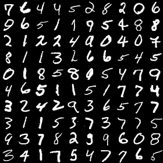

```julia
# Data
X, y = MLDatasets.MNIST(:train)[:]
y_enc = Flux.onehotbatch(y, 0:9)
Xtest, ytest = MLDatasets.MNIST(:test)[:]
ytest_enc = onehotbatch(ytest, 0:9)
mosaic(map(i -> convert2image(MNIST, X[:, :, i]), rand(1:60000, 100)), ncol=10)
```

We can preprocess the data as follows:

```julia
i_train, i_val = [], []
for (k, v) in group_indices(y)
    _i_train, _i_val = splitobs(v, at=0.7)
    push!(i_train, _i_train...)
    push!(i_val, _i_val...)
end
Xtrain, ytrain = X[:, :, i_train], y_enc[:, i_train]
Xval, yval = X[:, :, i_val], y_enc[:, i_val]
```

[output not shown]

Next, we define a data loader:

```julia
batchsize = 128
train_set = DataLoader((Xtrain, ytrain), batchsize=batchsize, shuffle=true)
val_set = DataLoader((Xval, yval), batchsize=batchsize)
```

```
141-element DataLoader(::Tuple{Array{Float32, 3}, OneHotMatrix{UInt32, Vector{UInt32}}}, batchsize=128)
  with first element:
  (28×28×128 Array{Float32, 3}, 10×128 OneHotMatrix(::Vector{UInt32}) with eltype Bool,)
```

We can now define a model, based on how we preprocessed the data:

```julia
model = Chain(
    Flux.flatten,
    Dense(28^2, 32, relu),
    Dense(32, 10),
    softmax
)
```

```
Chain(
  Flux.flatten,
  Dense(784 => 32, relu),               # 25_120 parameters
  Dense(32 => 10),                      # 330 parameters
  NNlib.softmax,
)                   # Total: 4 arrays, 25_450 parameters, 99.664 KiB.
```

Finally, what’s left to do is to define a loss function and an optimiser:

```julia
loss(y_hat, y) = Flux.Losses.crossentropy(y_hat, y)
opt_state = Flux.setup(Adam(), model)
```

Before we start training, we define some helper functions:

```julia
# Callbacks:
function accuracy(model, data::DataLoader)
    acc = 0
    for (x, y) in data
        acc += sum(onecold(model(x)) .== onecold(y)) / size(y, 2)
    end
    return acc / length(data)
end

function avg_loss(model, data::DataLoader)
    _loss = 0
    for (x, y) in data
        _loss += loss(model(x), y)[1]
    end
    return _loss / length(data)
end
```

As a very last step, we set up our training logs:

```julia
# Final setup:
nepochs = 100
acc_train, acc_val = accuracy(model, train_set), accuracy(model, val_set)
loss_train, loss_val = avg_loss(model, train_set), avg_loss(model, val_set)

log = DataFrame(
    epoch=0,
    acc_train=acc_train,
    acc_val=acc_val,
    loss_train=loss_train,
    loss_val=loss_val
)
```

Below we finally train our model:

```julia
# Training loop:
for epoch in 1:nepochs

    for (i, data) in enumerate(train_set)

        # Extract data:
        input, label = data

        # Compute loss and gradient:
        val, grads = Flux.withgradient(model) do m
            result = m(input)
            loss(result, label)
        end

        # Detect loss of Inf or NaN. Print a warning, and then skip update!
        if !isfinite(val)
            @warn "loss is $val on item $i" epoch
            continue
        end

        Flux.update!(opt_state, model, grads[1])

    end

    # Monitor progress:
    acc_train, acc_val = accuracy(model, train_set), accuracy(model, val_set)
    loss_train, loss_val = avg_loss(model, train_set), avg_loss(model, val_set)
    results = Dict(
        :epoch => epoch,
        :acc_train => acc_train,
        :acc_val => acc_val,
        :loss_train => loss_train,
        :loss_val => loss_val
    )
    push!(log, results)

    # Print progress:
    vals = Matrix(results_df[2:end,[:loss_train,:loss_val]])
    plt = UnicodePlots.lineplot(1:epoch, vals;
        name=["Train","Validation"], title="Loss in epoch $epoch", xlim=(1,nepochs))
    UnicodePlots.display(plt)

end
```

Figure 2.2 shows the training and validation loss and accuracy over epochs. The model is overfitting, as the validation loss increases after bottoming out at around epoch 20.

```julia
output = DataFrame(log)
output = output[2:end, :]

anim = @animate for epoch in 1:maximum(output.epoch)
    p_loss = plot(output[1:epoch, :epoch], Matrix(output[1:epoch, [:loss_train, :loss_val]]),
        label=["Train" "Validation"], title="Loss", legend=:topleft)
    p_acc = plot(output[1:epoch, :epoch], Matrix(output[1:epoch, [:acc_train, :acc_val]]),
        label=["Train" "Validation"], title="Accuracy", legend=:topleft)
    plot(p_loss, p_acc, layout=(1, 2), dpi=300, margin=5mm, size=(800, 400))
end
gif(anim, joinpath(www_path, "c4_mnist.gif"), fps=5)
```

[figure not shown]

Figure 2.2: Training and validation loss and accuracy